# Лабораторная 5. Toolbox

## 1. Какой бенчмарк уместен

Население Австралии почти прямая — дрейф. Кирпич и ягнята сезонные — SNAIVE. Богатство домохозяйств растёт без сезона — дрейф. Takeaway сезонный и растущий — SNAIVE как простой ориентир, дрейф сезон не повторит.

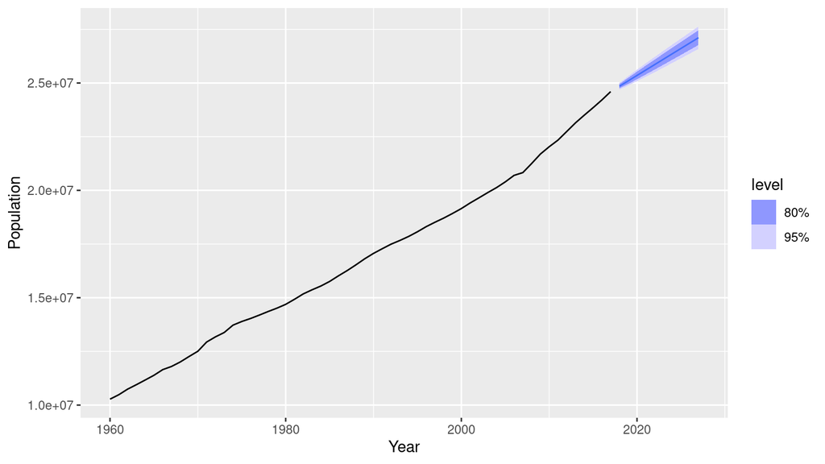

```r
aus_pop <- global_economy |>
  filter(Country == "Australia") |>
  select(Population)
bricks <- aus_production |> select(Bricks) |> filter(!is.na(Bricks))
lambs <- aus_livestock |>
  filter(State == "New South Wales", Animal == "Lambs")
wealth <- hh_budget |> select(Wealth)
takeaway <- aus_retail |>
  filter(Industry == "Takeaway food services") |>
  index_by(Month) |>
  summarise(Turnover = sum(Turnover))

fit_pop <- aus_pop |> model(RW(Population ~ drift()))
fit_bricks <- bricks |> model(SNAIVE(Bricks))
fit_lambs <- lambs |> model(SNAIVE(Count))
fit_wealth <- wealth |> model(RW(Wealth ~ drift()))
fit_take <- takeaway |> model(SNAIVE(Turnover))

autoplot(forecast(fit_pop, h = 10), aus_pop)
```

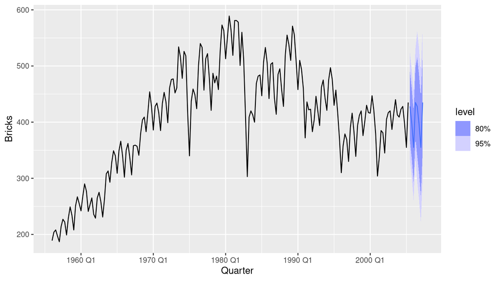

```r
autoplot(forecast(fit_bricks, h = 8), bricks)
```

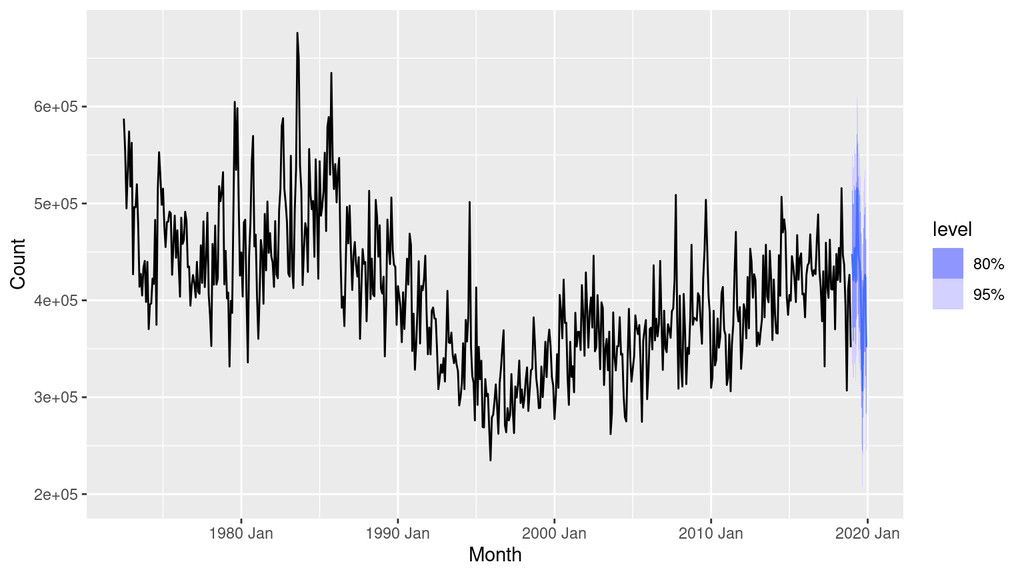

```r
autoplot(forecast(fit_lambs, h = 12), lambs)
```

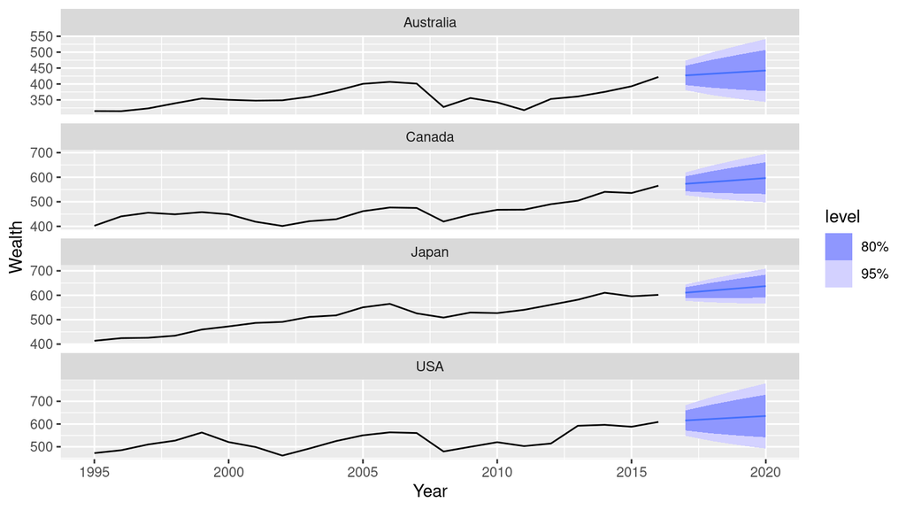

```r
autoplot(forecast(fit_wealth, h = 4), wealth)
```

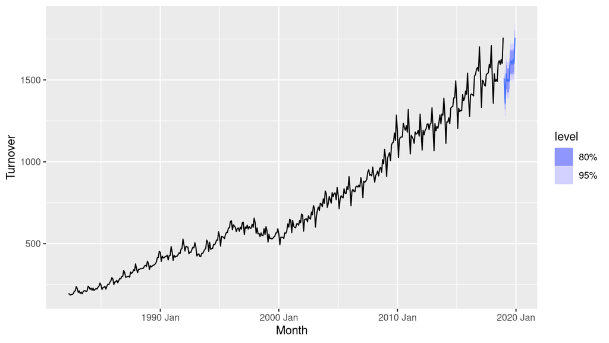

```r
autoplot(forecast(fit_take, h = 12), takeaway)
```

## 2. Facebook и дрейф

Дрейф: $\hat y_{T+h} = y_T + h(y_T - y_1)/(T-1)$. Это та же прямая, что через первую и последнюю точки, продолженная на $h$ шагов.

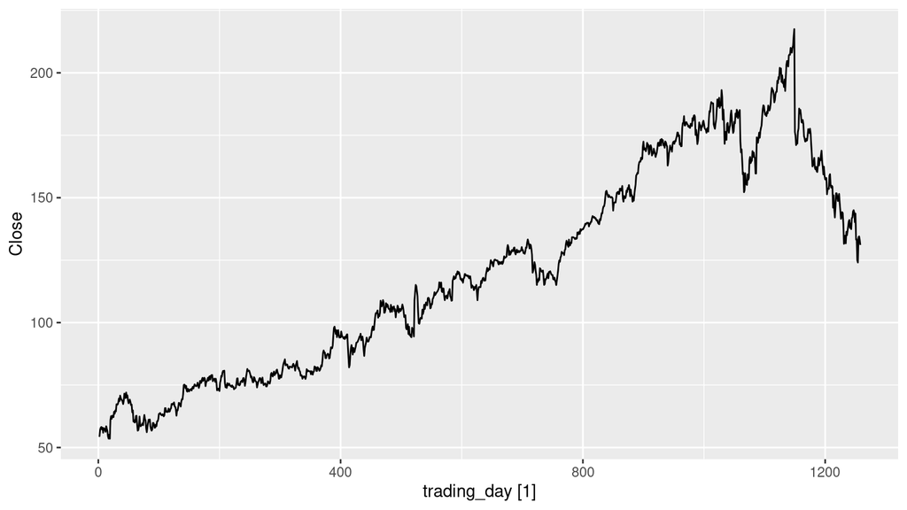

```r
fb <- gafa_stock |>
  filter(Symbol == "FB") |>
  mutate(trading_day = row_number()) |>
  update_tsibble(index = trading_day, regular = TRUE)
autoplot(fb, Close)
```

```r
n <- nrow(fb)
slope <- (fb$Close[n] - fb$Close[1]) / (n - 1)
h <- 1:30
line_fc <- fb$Close[n] + h * slope
fit_fb <- fb |> model(
  drift = RW(Close ~ drift()),
  naive = NAIVE(Close),
  mean = MEAN(Close)
)
fc_fb <- forecast(fit_fb |> select(drift), h = 30)
max(abs(as_tibble(fc_fb)$.mean - line_fc))
```

```
## [1] 2.842171e-14
```

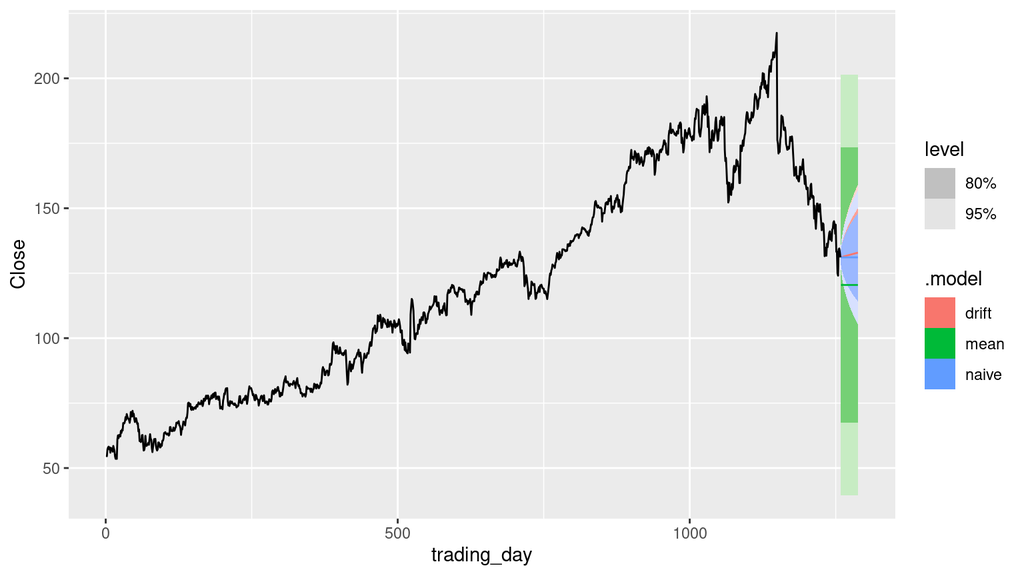

```r
autoplot(forecast(fit_fb, h = 30), fb)
```

Разница дрейфа и прямой — машинный ноль. Среднее и наивный без дрейфа хуже: у цены есть наклон, а сезона, который стоило бы копировать, нет. Дрейф здесь лучший из трёх простых методов, хотя для цены это всё равно не модель доходности.

## 3. Пиво с 1992 года

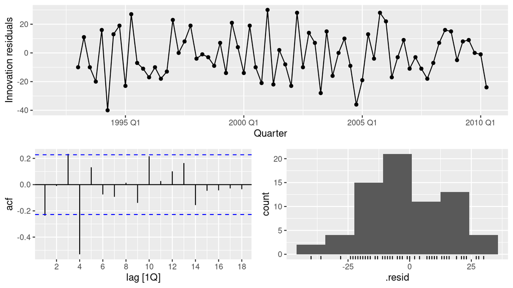

```r
beer <- aus_production |>
  select(Beer) |>
  filter(year(Quarter) >= 1992)
fit_beer <- beer |> model(SNAIVE(Beer))
gg_tsresiduals(fit_beer)
```

```r
augment(fit_beer) |> features(.innov, ljung_box, lag = 8)
```

```
## # A tibble: 1 × 3
##   .model       lb_stat lb_pvalue
##   <chr>          <dbl>     <dbl>
## 1 SNAIVE(Beer)    32.3 0.0000834
```

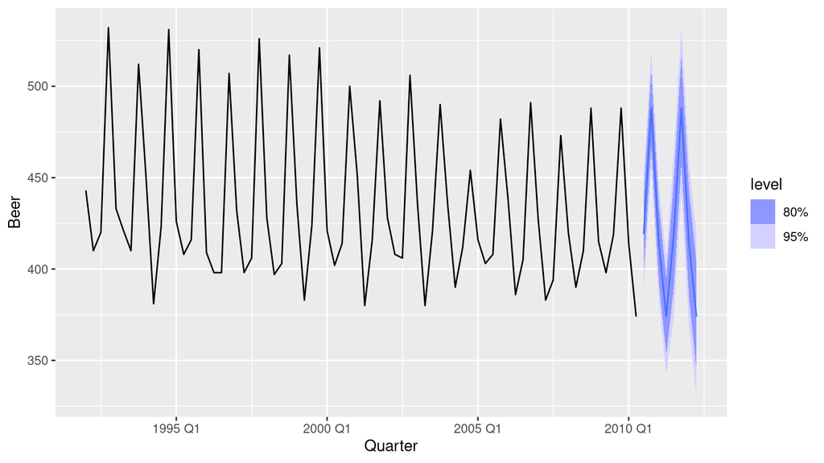

```r
autoplot(forecast(fit_beer, h = 8), beer)
```

## 4. Экспорт и кирпич

Экспорт Австралии — годовой ряд без сезона, беру наивный (случайное блуждание): долгосрочного ровного наклона, как у населения, нет. Кирпич квартальный, сезонный — SNAIVE.

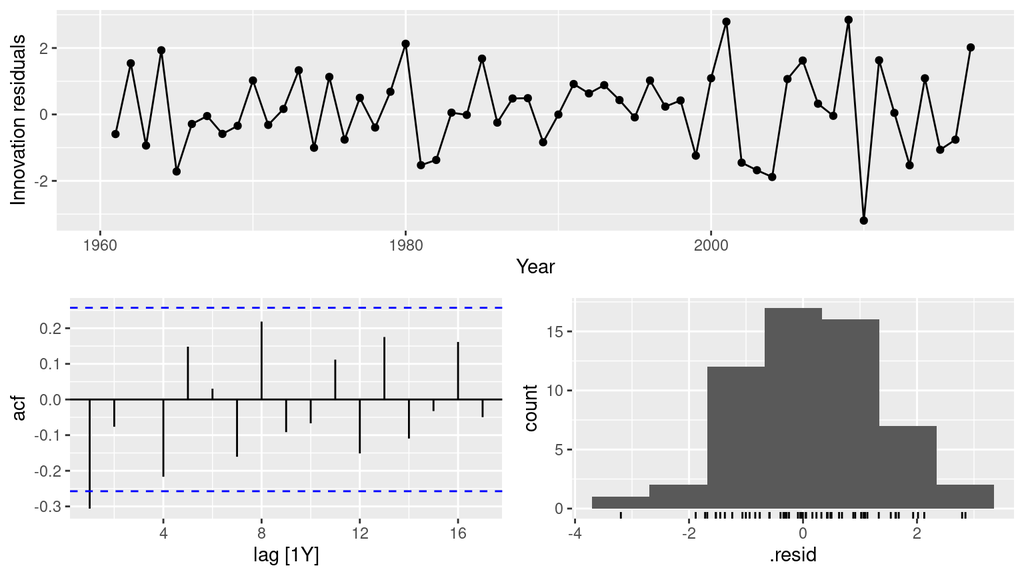

```r
exports <- global_economy |>
  filter(Country == "Australia") |>
  select(Exports)
fit_exp <- exports |> model(NAIVE(Exports))
gg_tsresiduals(fit_exp)
```

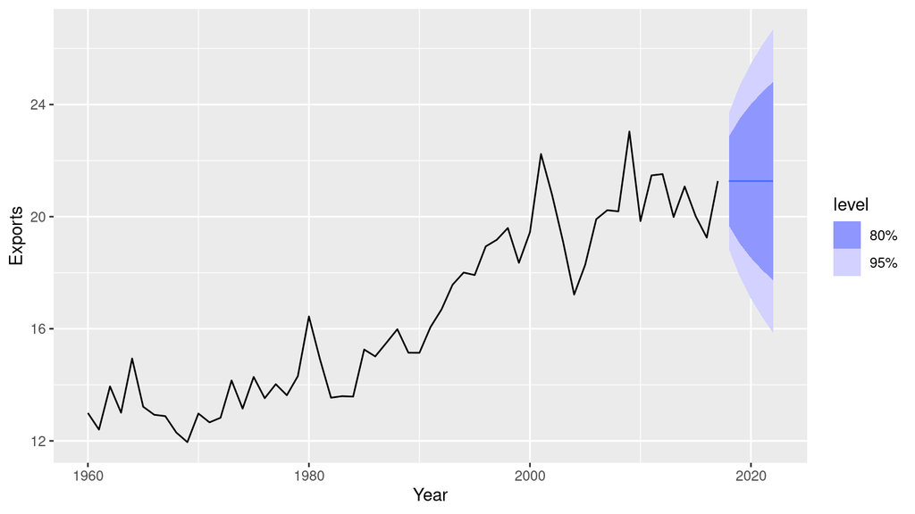

```r
autoplot(forecast(fit_exp, h = 5), exports)
```

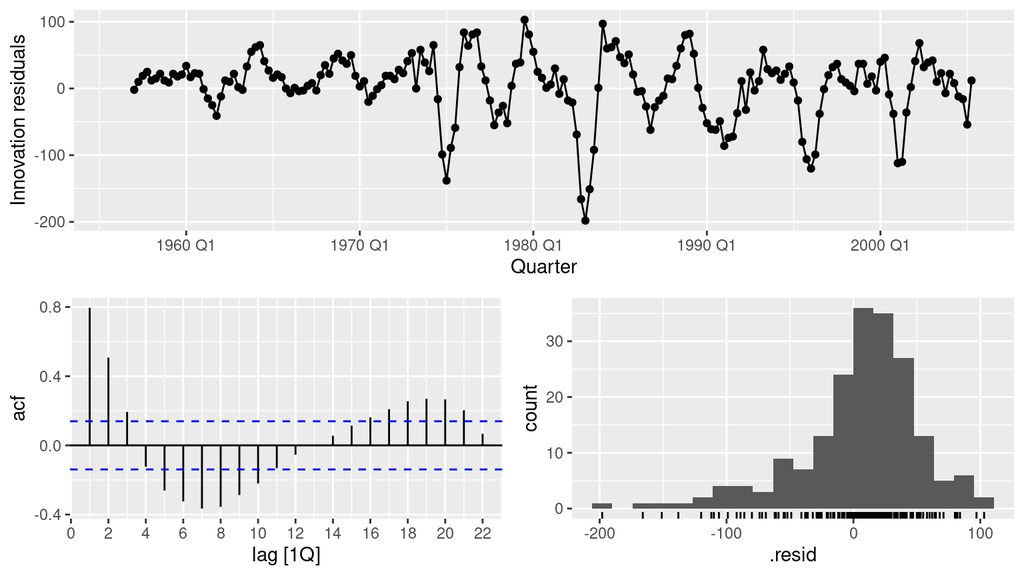

```r
fit_br <- bricks |> model(SNAIVE(Bricks))
gg_tsresiduals(fit_br)
```

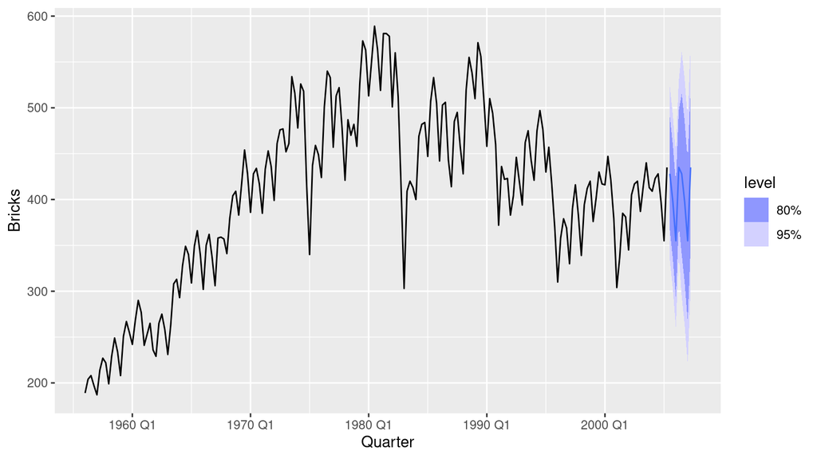

```r
autoplot(forecast(fit_br, h = 8), bricks)
```

У экспорта остатки похожи на шум вокруг нуля, наивный уместен. У кирпича сезон сильный, но есть ещё тренд и обрыв производства: SNAIVE повторяет последний год и не продолжает спад. Остатки из-за этого не белый шум.

## 5. Семь рядов Victoria

[figure not shown]

```r
vic <- aus_livestock |> filter(State == "Victoria")
fit_vic <- vic |> model(SNAIVE(Count))
autoplot(forecast(fit_vic, h = 12), vic)
```

Для рядов с устойчивым сезоном и без сильного тренда это нормальная точка отсчёта. Там, где есть долгий спад или рост (часть поголовья), SNAIVE застывает на последнем годе и как прогноз уровня слабоват. Как бенчмарк, который обязан обойти более сложная модель, он всё равно полезен.

## 6. Верно или нет

1. «Хороший метод обязан иметь нормальные остатки» — нет. Для точечного прогноза важны нулевое среднее и отсутствие корреляции. Нормальность нужна, только если интервалы строятся из нормального закона.
2. «Маленькие остатки дают хороший прогноз» — нет. Остатки считаются на обучении. Модель может заучить историю и развалиться на новых данных.
3. «Лучшая мера точности — MAPE» — нет. При значениях около нуля MAPE взрывается, и она не симметрична. RMSE или MAE часто честнее; меру выбирают под задачу.
4. «Если прогнозирует плохо, усложняй» — нет. Сначала проверить данные, преобразование и бенчмарк. Лишние параметры подгоняют шум.
5. «Всегда бери модель с лучшей точностью на тесте» — нет. Один тестовый кусок случаен. Перебор десятков моделей на том же тесте подгоняет уже тест. Разницу в третьем знаке MAPE не стоит считать победой.

## 7. Розничный ряд до 2011

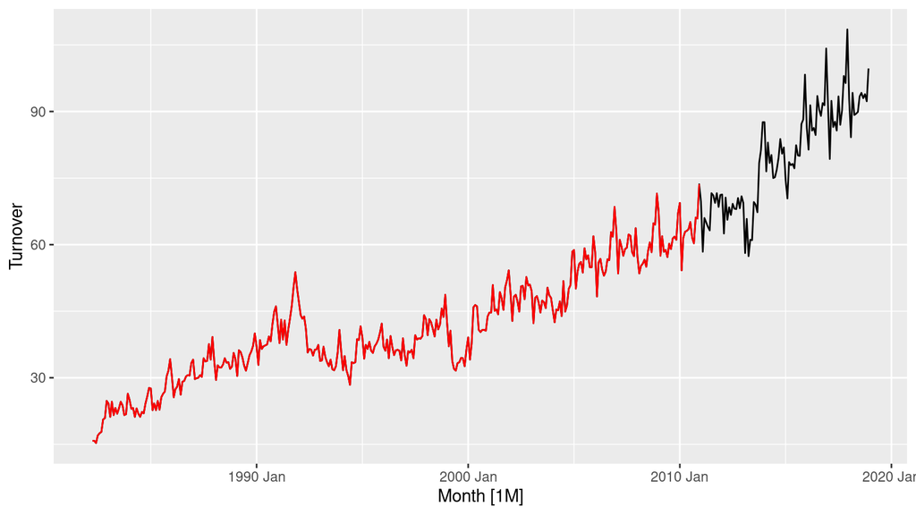

```r
myseries_train <- myseries |> filter(year(Month) < 2011)
autoplot(myseries, Turnover) +
  autolayer(myseries_train, Turnover, colour = "red")
```

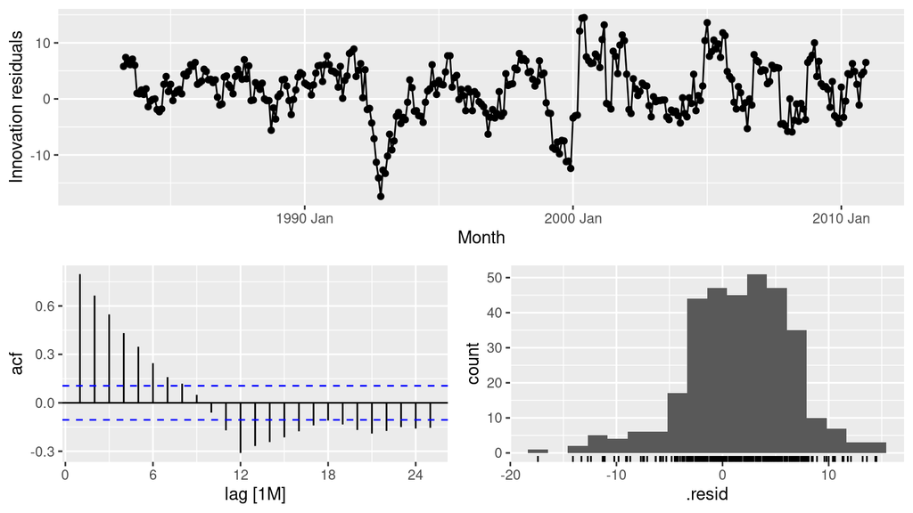

```r
fit_retail <- myseries_train |> model(SNAIVE(Turnover))
gg_tsresiduals(fit_retail)
```

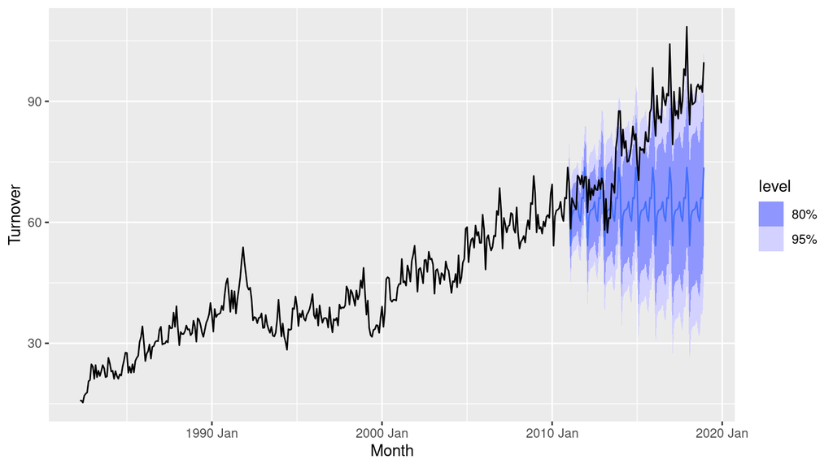

```r
fc_retail <- forecast(fit_retail, h = nrow(anti_join(myseries, myseries_train)))
autoplot(fc_retail, myseries)
```

```r
accuracy(fc_retail, myseries)
```

```
## # A tibble: 1 × 12
##   .model    State Industry .type    ME  RMSE   MAE   MPE  MAPE  MASE RMSSE  ACF1
##   <chr>     <chr> <chr>    <chr> <dbl> <dbl> <dbl> <dbl> <dbl> <dbl> <dbl> <dbl>
## 1 SNAIVE(T… Sout… Takeawa… Test   15.9  19.2  16.2  18.5  19.0  3.94  3.70 0.907
```

```r
train_late <- myseries |> filter(year(Month) >= 2005, year(Month) < 2011)
fit_late <- train_late |> model(SNAIVE(Turnover))
fc_late <- forecast(fit_late, new_data = anti_join(myseries, myseries_train))
accuracy(fc_late, myseries)
```

```
## # A tibble: 1 × 12
##   .model    State Industry .type    ME  RMSE   MAE   MPE  MAPE  MASE RMSSE  ACF1
##   <chr>     <chr> <chr>    <chr> <dbl> <dbl> <dbl> <dbl> <dbl> <dbl> <dbl> <dbl>
## 1 SNAIVE(T… Sout… Takeawa… Test   15.9  19.2  16.2  18.5  19.0  3.94  3.70 0.907
```

```r
accuracy(fc_retail, myseries)
```

```
## # A tibble: 1 × 12
##   .model    State Industry .type    ME  RMSE   MAE   MPE  MAPE  MASE RMSSE  ACF1
##   <chr>     <chr> <chr>    <chr> <dbl> <dbl> <dbl> <dbl> <dbl> <dbl> <dbl> <dbl>
## 1 SNAIVE(T… Sout… Takeawa… Test   15.9  19.2  16.2  18.5  19.0  3.94  3.70 0.907
```

Остатки SNAIVE коррелированы: кроме сезона в ряде есть тренд, и копирование прошлого года его не снимает. На нормальность они тоже не похожи. Точность слабо зависит от того, взять ли всю историю до 2011 или только 2005–2010: сезонный наивный и так смотрит лишь на последний год обучения.

## 8. Свиньи, New South Wales

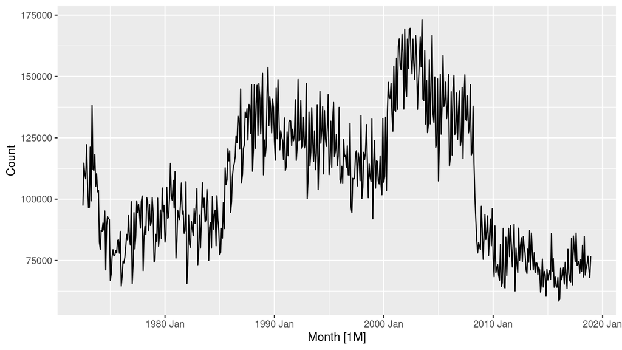

```r
pigs <- aus_livestock |>
  filter(State == "New South Wales", Animal == "Pigs")
autoplot(pigs, Count)
```

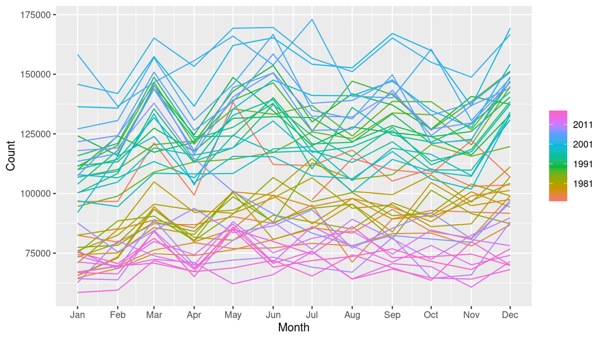

```r
gg_season(pigs, Count)
```

```r
n_test <- 72
pigs_train <- pigs |> slice_head(n = nrow(pigs) - n_test)
pigs_test <- anti_join(pigs, pigs_train)
c(train = nrow(pigs_train), test = nrow(pigs_test))
```

```
## train  test
##   486    72
```

```r
fit_pigs <- pigs_train |>
  model(
    mean = MEAN(Count),
    naive = NAIVE(Count),
    snaive = SNAIVE(Count),
    drift = RW(Count ~ drift())
  )
fc_pigs <- forecast(fit_pigs, new_data = pigs_test)
accuracy(fc_pigs, pigs) |> arrange(RMSE)
```

```
## # A tibble: 4 × 12
##   .model Animal State       .type      ME   RMSE    MAE    MPE  MAPE  MASE RMSSE
##   <chr>  <fct>  <fct>       <chr>   <dbl>  <dbl>  <dbl>  <dbl> <dbl> <dbl> <dbl>
## 1 drift  Pigs   New South … Test   -4685.  8091.  6967.  -7.36  10.1 0.657 0.557
## 2 naive  Pigs   New South … Test   -6138.  8941.  7840.  -9.39  11.4 0.740 0.615
## 3 snaive Pigs   New South … Test   -5838. 10111.  8174.  -8.81  11.9 0.771 0.696
## 4 mean   Pigs   New South … Test  -39360. 39894. 39360. -55.9   55.9 3.71  2.75
## # ℹ 1 more variable: ACF1 <dbl>
```

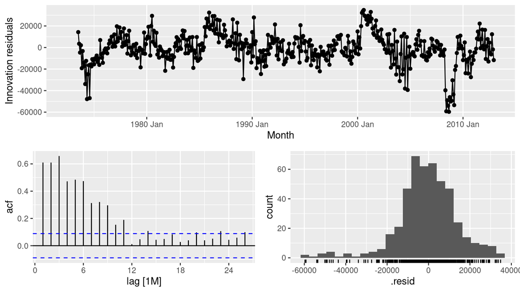

```r
gg_tsresiduals(fit_pigs |> select(snaive))
```

Лучший по RMSE на тесте — тот, у кого меньше ошибка в таблице `accuracy` (обычно SNAIVE или дрейф, если есть наклон). Остатки выбранного сезонного наивного не белый шум, если в ряде остался тренд: бенчмарк всё равно оставляем как точку сравнения.

## 9. Богатство, последние 4 года

```r
wealth_train <- wealth |> filter(Year <= max(Year) - 4)
wealth_test <- anti_join(wealth, wealth_train)
fit_w <- wealth_train |>
  model(
    mean = MEAN(Wealth),
    naive = NAIVE(Wealth),
    drift = RW(Wealth ~ drift())
  )
fc_w <- forecast(fit_w, new_data = wealth_test)
accuracy(fc_w, wealth) |>
  group_by(.model) |>
  summarise(RMSE = mean(RMSE), MAPE = mean(MAPE)) |>
  arrange(RMSE)
```

```
## # A tibble: 3 × 3
##   .model  RMSE  MAPE
##   <chr>  <dbl> <dbl>
## 1 drift   41.7  7.12
## 2 naive   53.2  9.23
## 3 mean    79.9 14.1
```

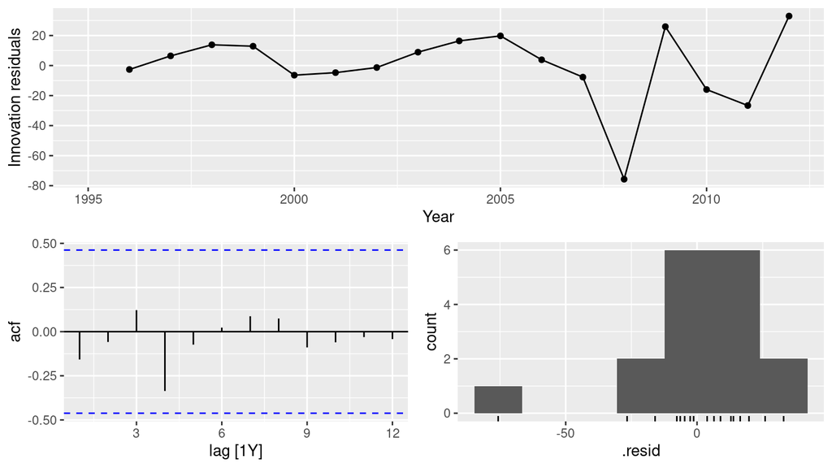

```r
best_w <- accuracy(fc_w, wealth) |>
  group_by(.model) |>
  summarise(RMSE = mean(RMSE)) |>
  slice_min(RMSE, n = 1, with_ties = FALSE) |>
  pull(.model)
gg_tsresiduals(fit_w |> filter(Country == "Australia") |> select(all_of(best_w)))
```

## 10. Takeaway, последние 4 года

```r
take_train <- takeaway |> filter(year(Month) <= max(year(Month)) - 4)
take_test <- anti_join(takeaway, take_train)
fit_t <- take_train |>
  model(
    mean = MEAN(Turnover),
    naive = NAIVE(Turnover),
    snaive = SNAIVE(Turnover),
    drift = RW(Turnover ~ drift())
  )
fc_t <- forecast(fit_t, new_data = take_test)
accuracy(fc_t, takeaway) |> arrange(RMSE)
```

```
## # A tibble: 4 × 10
##   .model .type    ME  RMSE   MAE   MPE  MAPE  MASE RMSSE  ACF1
##   <chr>  <chr> <dbl> <dbl> <dbl> <dbl> <dbl> <dbl> <dbl> <dbl>
## 1 naive  Test  -12.4  119.  96.4 -1.49  6.66  2.30  2.25 0.613
## 2 drift  Test  -93.7  130. 108.  -6.82  7.67  2.58  2.46 0.403
## 3 snaive Test  177.   192. 177.  11.7  11.7   4.22  3.64 0.902
## 4 mean   Test  829.   838. 829.  55.7  55.7  19.8  15.8  0.613
```

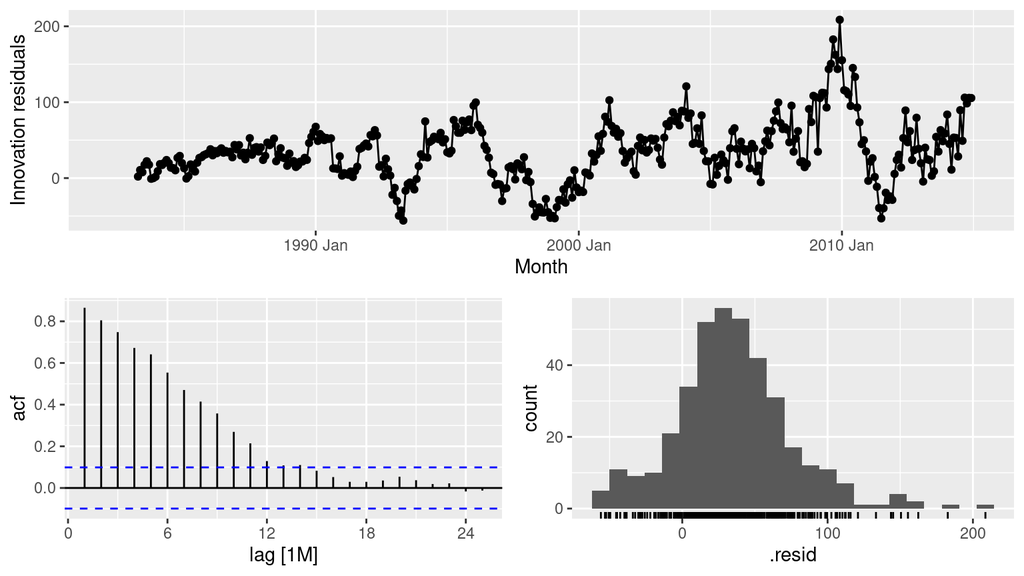

```r
gg_tsresiduals(fit_t |> select(snaive))
```

## 11. Кирпич и STL

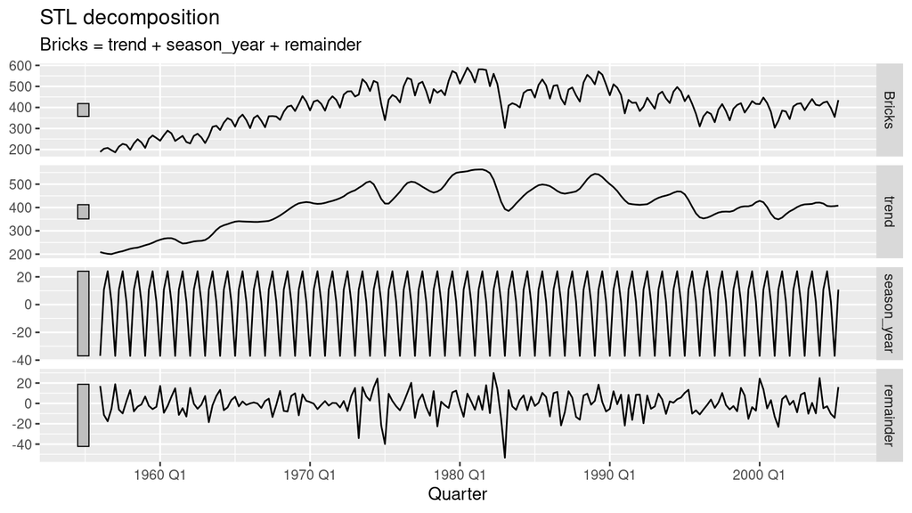

```r
fit_stl <- bricks |>
  model(
    fixed = decomposition_model(
      STL(Bricks ~ season(window = "periodic")),
      NAIVE(season_adjust)
    ),
    changing = decomposition_model(
      STL(Bricks ~ season(window = 7)),
      NAIVE(season_adjust)
    ),
    robust = decomposition_model(
      STL(Bricks ~ season(window = "periodic"), robust = TRUE),
      NAIVE(season_adjust)
    )
  )
stl_fixed <- bricks |> model(STL(Bricks ~ season(window = "periodic")))
components(stl_fixed) |> autoplot()
```

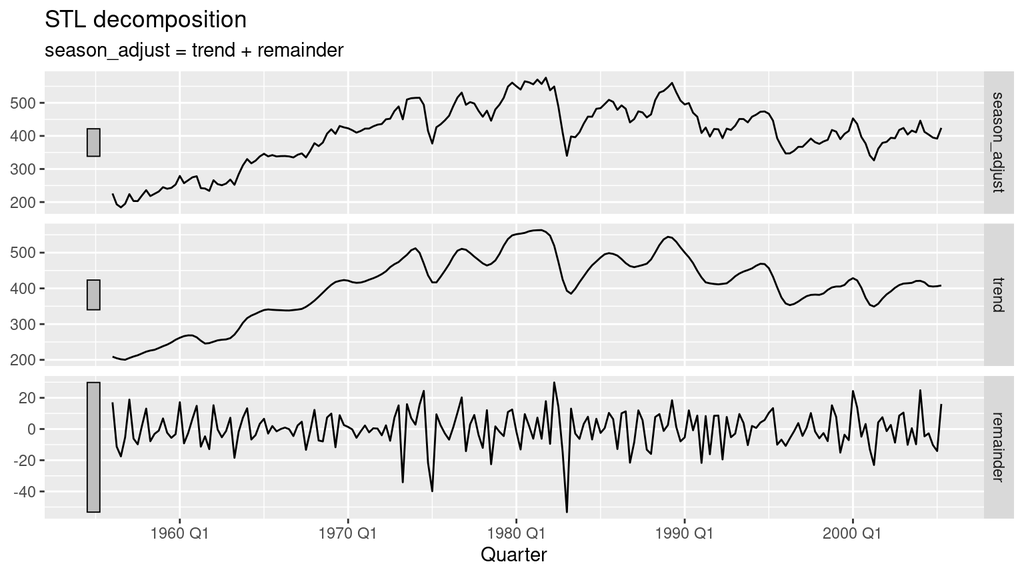

```r
components(stl_fixed) |> autoplot(season_adjust)
```

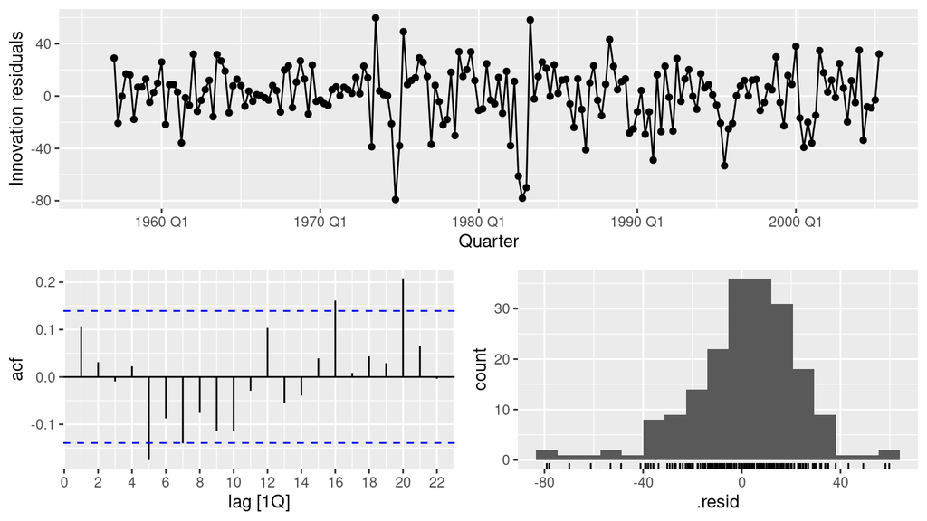

```r
gg_tsresiduals(fit_stl |> select(fixed))
```

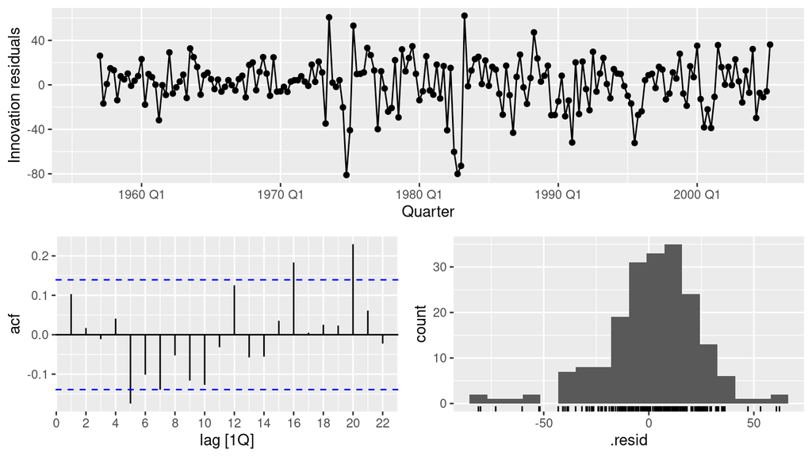

```r
gg_tsresiduals(fit_stl |> select(robust))
```

Сезонно сглаженный ряд — это тренд плюс остаток. Наивный метод тянет его вперёд по последнему значению, `decomposition_model` возвращает сезон. Робастный STL почти не меняет картину, если сильных выбросов мало. Остатки не вполне белый шум: в кирпиче есть переломы уровня.

```r
bricks_train <- bricks |> slice_head(n = nrow(bricks) - 8)
bricks_test <- anti_join(bricks, bricks_train)
cmp <- bricks_train |>
  model(
    stl = decomposition_model(
      STL(Bricks ~ season(window = "periodic")),
      NAIVE(season_adjust)
    ),
    snaive = SNAIVE(Bricks)
  )
fc_br <- forecast(cmp, new_data = bricks_test)
accuracy(fc_br, bricks)
```

```
## # A tibble: 2 × 10
##   .model .type    ME  RMSE   MAE   MPE  MAPE  MASE RMSSE    ACF1
##   <chr>  <chr> <dbl> <dbl> <dbl> <dbl> <dbl> <dbl> <dbl>   <dbl>
## 1 snaive Test   2.75  20    18.2 0.395  4.52 0.504 0.407 -0.0503
## 2 stl    Test   8.00  18.1  13.8 1.82   3.36 0.380 0.368  0.0957
```

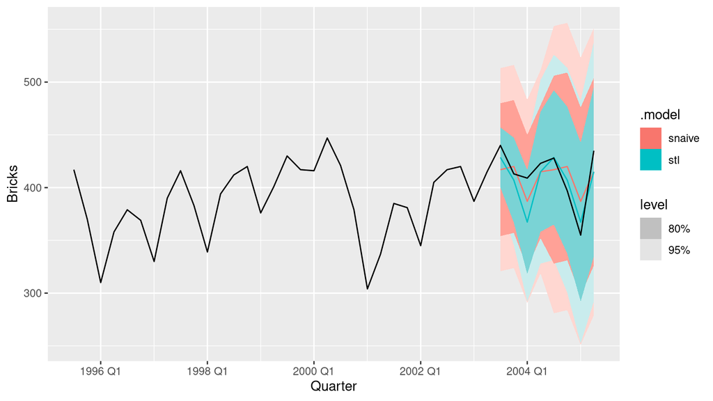

```r
autoplot(fc_br, bricks |> slice_tail(n = 40))
```

На последних двух годах выигрывает тот метод, у которого меньше RMSE. Если уровень в конце падает, наивный по сглаженному ряду и SNAIVE оба запаздывают; STL чуть честнее, когда сезон менялся.

## 12. Gold Coast

```r
gc_tourism <- tourism |>
  filter(Region == "Gold Coast") |>
  index_by(Quarter) |>
  summarise(Trips = sum(Trips))
train_for <- function(years_held) {
  gc_tourism |> slice_head(n = nrow(gc_tourism) - 4 * years_held)
}
fits <- list(
  gc_fc_1 = train_for(1) |> model(SNAIVE(Trips)) |> forecast(h = 4),
  gc_fc_2 = train_for(2) |> model(SNAIVE(Trips)) |> forecast(h = 4),
  gc_fc_3 = train_for(3) |> model(SNAIVE(Trips)) |> forecast(h = 4)
)
bind_rows(lapply(names(fits), function(nm) {
  accuracy(fits[[nm]], gc_tourism) |> mutate(window = nm)
})) |> select(window, MAPE, RMSE)
```

```
## # A tibble: 3 × 3
##   window   MAPE  RMSE
##   <chr>   <dbl> <dbl>
## 1 gc_fc_1 15.1  167.
## 2 gc_fc_2  4.32  43.1
## 3 gc_fc_3  9.07  91.4
```

MAPE скачет от года к году: один тестовый год — слишком короткая проверка. Сезонный наивный стабилен как метод, но оценка его точности на одном годе шумная.